# Zonas con mayor índice de pobreza en la República Mexicana

Laura Platas Valle, Angel Orlando Rangel Gonzalez, Saul Emiliano Toledo Morales, Alan Mauricio Ortiz Horta

6/1/2021

#A lo largo de este proyecto se identificaran las zonas con el mayor indice de pobreza en el país. Con la ayuda de r se organizaran los datos a partir de matrices y mapas. La información se obtuvo del CONEVAL (concejo nacional de evaluacion de la política de desarrollo social) y del diario de la federación

```r
library(ggmap)
```

#A través del diario de la federación se identificaron cuatro grupos vulnerables en situacion de pobreza

```r
poblacion_indigena<-c(69.6)
personas_con_discapacidad<-c(48.6)
personas_mayores_de_65<-c(41.1)
jovenes_de_12_a_29_años<-c(42.4)

pb<-matrix(c(poblacion_indigena,personas_con_discapacidad,personas_mayores_de_65,jovenes_de_12_a_29_años),nrow = 4)
colnames(pb)=c("porcentaje_de_pobreza")
rownames(pb)=c("poblacion_indigena","personas_con_discapacidad","personas_mayores_de_65","jovenes_de_12_a_29_años")
pb
```

```
##                           porcentaje_de_pobreza
## poblacion_indigena                         69.6
## personas_con_discapacidad                  48.6
## personas_mayores_de_65                     41.1
## jovenes_de_12_a_29_años                    42.4
```

#De igual manera se presentan estos cuatro grupos en situacion de pobreza extrema

```r
poblacion_indigena<-c(27.9)
personas_con_discapacidad<-c(9.8)
personas_mayores_de_65<-c(6.8)
jovenes_de_12_a_29_años<-c(7.1)

pb<-matrix(c(poblacion_indigena,personas_con_discapacidad,personas_mayores_de_65,jovenes_de_12_a_29_años),nrow = 4)
colnames(pb)=c("porcentaje_de_pobreza_exrema")
rownames(pb)=c("poblacion_indigena","personas_con_discapacidad","personas_mayores_de_65","jovenes_de_12_a_29_años")
pb
```

```
##                           porcentaje_de_pobreza_exrema
## poblacion_indigena                                27.9
## personas_con_discapacidad                          9.8
## personas_mayores_de_65                             6.8
## jovenes_de_12_a_29_años                            7.1
```

#Segun el CONEVAL y el diario oficial de la federación hay cinco estados en los cuales se concentra la mayor cantidad de pobreza del pais

```r
Chiapas<-c(76.4)
Guerrero<-c(66.5)
Oaxaca<-c(66.4)
Veracruz<-c(61.8)
Puebla<-c(58.9)

mx<-matrix(c(Chiapas,Guerrero,Oaxaca,Veracruz,Puebla),nrow = 5)
colnames(mx)=c("Porcentaje_de_pobreza")
rownames(mx)=c("Chiapas","Guerrero","Oaxaca","Veracruz","Puebla")
mx
```

```
##          Porcentaje_de_pobreza
## Chiapas                   76.4
## Guerrero                  66.5
## Oaxaca                    66.4
## Veracruz                  61.8
## Puebla                    58.9
```

#Seguido de esto ubicaremos los estados con mayor indice de pobraza, para poder vizualizar mejor la linea divizoria de marginalidad, debdidoa a que muchos de estos se ecuentran en la zona sur del país

```r
Chiapas<-c(17.5565300,-93.3810400)
Guerrero<-c(16.775,-93.7417)
Oaxaca<-c(17.0669,-96.7203)
Veracruz<-c(19.1727,-96.1333)
Puebla<-c(19.0413,-98.2062)

Mexico<-rbind(Chiapas,Guerrero,Oaxaca,Veracruz,Puebla)
colnames(Mexico)=c("latitud","longitud")
Mexico
```

```
##           latitud  longitud
## Chiapas  17.55653 -93.38104
## Guerrero 16.77500 -93.74170
## Oaxaca   17.06690 -96.72030
## Veracruz 19.17270 -96.13330
## Puebla   19.04130 -98.20620
```

```r
Mexico<-data.frame(Mexico)
Mexico
```

```
##           latitud  longitud
## Chiapas  17.55653 -93.38104
## Guerrero 16.77500 -93.74170
## Oaxaca   17.06690 -96.72030
## Veracruz 19.17270 -96.13330
## Puebla   19.04130 -98.20620
```

#Utilizando la funcion qmplot se graficarion 5 puntos de difernte color puestos función rainwbox, dejando ver el punto de la latitud 16 desde el cual se va mostrando las regiones de marginalidad

```
## Using zoom = 8...
```

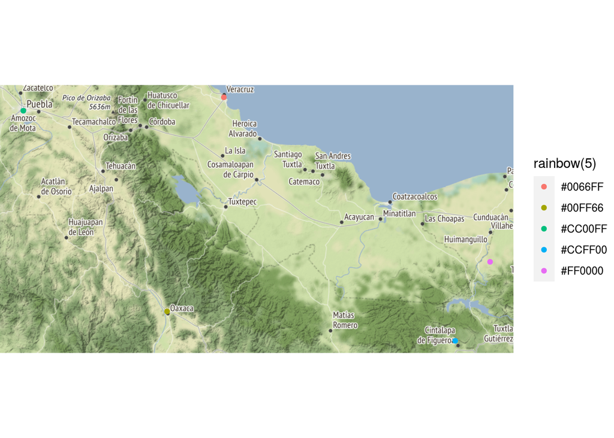

```r
qmplot(longitud,latitud, data = Mexico, color=rainbow(5))
```

#matriz por renglones acerca de los estados con mayor concentracion de pobreza en la replublica mexicana

```r
n<-c("Chiapas","Guerrero","Oaxaca")
o<-c("Veracruz","Puebla","otros")
p<-rbind(n,o)
colnames(p)<-c("Pais","Estado","Concentracion de pobreza")
rownames(p)<-c("Fila N","Fila O")
p
```

```
##        Pais       Estado     Concentracion de pobreza
## Fila N "Chiapas"  "Guerrero" "Oaxaca"
## Fila O "Veracruz" "Puebla"   "otros"
```

#LINK AL VIDEO TUTORIAL.

[video not shown]